# Kaggle - FE - HT - XGBoost - report - Rocky Wang

2022-12-02

#### Background

For this competition, our goal is to build a solid model to predict the rating of a song. More specifically, the data set contains auditory features like loudness and tempo, as well as performers’ demographic information, which are all important factors for songs. Our key task is to pick the most powerful predictors and the most efficient model for the scenario.

```r
#load library

library(tidyverse)
library(caret)
library(xgboost)
library(qdapTools)
```

Load tidyverse for a set of useful packages, such as dplyr(data manipulation) and ggplots(data visualization) Load caret to streamline the process for creating predictive models Load xgboost for the powerful regression model Load qdapTools so ‘mtabulate’ function is viable

```r
#load data

set.seed(1025)

songs <- read.csv('analysisData.csv')
scoringData <- read.csv('scoringData.csv')

song <- songs[,-c(1,3)]
scordata <- scoringData[,-c(1,3)]
```

To generate reproducible results, we set a seed for the entire scripts. Then CSV files were loaded into data frames. Since both id and song columns serve as unique identifiers which won’t make any contribution to our model, they are excluded from future analysis.

```r
#feature engineering - genre

song$genre <- gsub('\\[','',song$genre)
song$genre <- gsub('\\]','',song$genre)
song$genre <- gsub("\\'",'',song$genre)

song$genre <- strsplit(song$genre,',')
song <- cbind(song, mtabulate(song$genre))

scordata$genre <- gsub('\\[','',scordata$genre)
scordata$genre <- gsub('\\]','',scordata$genre)
scordata$genre <- gsub("\\'",'',scordata$genre)

scordata$genre <- strsplit(scordata$genre,',')
scordata <- cbind(scordata, mtabulate(scordata$genre))

shared_g <- intersect(names(song), names(scordata))

scordata <- select(scordata,all_of(shared_g))
song <- select(song,c('rating',all_of(shared_g)))
```

Genre column seems to contains a lot of information, to make this feature usable, we need to engineer a little bit. The original genre contains special characters ([,],’), we firstly delete them by replacing these character with blank string. Then everything left that separates genre names is the comma, we use string split function and set “,” as the delimiter. After perform this action on both data sets, we noticed there are many more genre names extract from song data than scordata. Since our ultimate goal is to develop a model that predict the rating of songs from scordata, it is logical for us to only include anything appears in both data sets as our predictors. We find come genre names and exclude the rest.

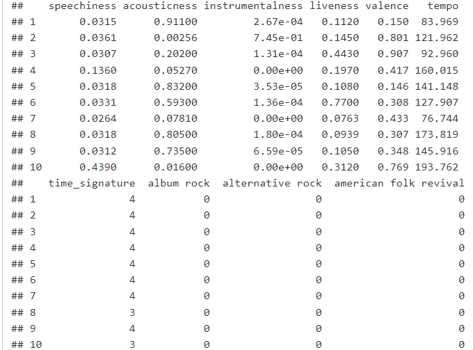

```r
#Sample results for engineered genre

knitr::include_graphics("Adjusted genre.png")
```

```r
#feature engineering - performer

song$performer <- strsplit(song$performer,' ')
song <- cbind(song, mtabulate(song$performer))

scordata$performer <- strsplit(scordata$performer,' ')
scordata <- cbind(scordata, mtabulate(scordata$performer))

shared_p <- intersect(names(song), names(scordata))

scordata <- select(scordata,all_of(shared_p))
song <- select(song,c('rating',all_of(shared_p)))
```

Using space as a delimiter to separate performers’ name and make each unique elements (first name/last name/special characters) as a column. Again, we only want to include common elements that appear in both data sets. Find the intersection and exclude the rest from both data frame.

PS : One thing that I could have done better is to further exclude special characters like $, % or ’. Most of them are used to decorate pseudonyms, though it might provide minimal contribution on the ratings, considering the large pool of names from performers, I think they are neglectable.

```r
#feature engineering - track_explicit

scordata$track_explicit <- as.numeric(scordata$track_explicit)
song$track_explicit <- as.numeric(song$track_explicit)
```

Track_explicit is a categorical variable, we convert it to a dummy binary variable

```r
#split into training and testing data set

song <- song[,-c(2,3)]
scordata <- scordata[,-c(1,2)]

parts <- createDataPartition(song$rating, p = .8, list = F)
train <- song[parts, ]
test <- song[-parts, ]
```

To finalize both data frames, we delete the original genre and performer columns from the data sets. Though for this competition the while ‘analysisData.csv’ serves as the training set, I decided to divide it further so I can test the performance of my model before submitting. One possible benefit could be the prevention of over fitting.

```r
#define predictor and response variables

train_x <- data.matrix(train[, -1])
train_y <- train[,'rating']

test_x <- data.matrix(test[, -1])
test_y <- test[, 'rating']
```

For this model, ‘rating’ is our target variable and everything else serves as predictors. Since XGBoost only take certain format for input data, we convert predictors portion into data matrix.

#### Model - RGBoost Regression

In this section, my first pale try was using neural network(attached separately), however, with the fact that neural network performs better with images and texts, this was not a convincing choice. And when it comes to the traditional regression models, XGBoost regression is one of the most powerful models I know, so I headed that way. Still, the result of neural network using the original data did generate a good RMSE, therefore, I dig deeper into the part of feature engineering before applying the XGBoost regression.

```r
#hyper parameter grid

hyper_grid <- expand.grid(
  eta = 0.01,
  max_depth = c(3,6),
  min_child_weight = c(1,3,5),
  subsample = c(0.2,0.5,0.8),
  colsample_bytree = c(0.2,0.5,0.8),
  gamma = c(0, 1, 10),
  lambda = c(0, 1e-2, 0.1, 1, 100),
  alpha = c(0, 1e-2, 0.1, 1, 100),
  rmse = 0,          # a place to dump RMSE results
  trees = 0          # a place to dump required number of trees
)
```

The hyper parameter grid enables us to fill in any values we want to test for each parameter, still, the assign of value should be a reasonable try for each particular parameter. For example, subsample ranges from 0 to 1, gamma ranges from 0 to infinite. Also, we leave rmse and trees as blank for now since we will grab these from the iteration that output the lowest RMSE.

[figure not shown]

```r
#Sample results for grid research

knitr::include_graphics("Grid.png")
```

```r
#results

hyper_grid %>%
  filter(rmse > 0) %>%
  arrange(rmse) %>%
  glimpse()
```

```
## Rows: 0
## Columns: 10
## $ eta              <dbl>
## $ max_depth        <dbl>
## $ min_child_weight <dbl>
## $ subsample        <dbl>
## $ colsample_bytree <dbl>
## $ gamma            <dbl>
## $ lambda           <dbl>
## $ alpha            <dbl>
## $ rmse             <dbl>
## $ trees            <dbl>
```

```r
#optimal parameter list

params <- list(
  eta = 0.01,
  max_depth = 3,
  min_child_weight = 3,
  subsample = 0.5,
  colsample_bytree = 0.5,
  gamma=0,
  lambda=1e+00,
  alpha=0)
```

```r
#train final model

xgb.fit.final <- xgboost(
  params = params,
  data = as.matrix(train_x),
  label = train_y,
  nrounds = 3147,
  objective = "reg:squarederror",
  verbose = 0)
```

Use the optimal parameters to train the model.

```r
#check performance with test set

pred_t <- predict(xgb.fit.final, test_x)
head(pred_t, n=47)
```

```
##  [1] 26.81670 39.73659 33.20694 36.39149 33.03021 29.70132 29.60744 38.00028
##  [9] 25.51627 42.89131 37.72474 24.79145 29.31310 36.86318 28.71904 21.73402
## [17] 35.62691 38.53580 26.72920 30.22940 48.33412 32.87998 29.73380 34.19034
## [25] 37.62576 34.86309 22.89024 37.73907 32.08433 36.47561 29.74531 32.96865
## [33] 32.19441 26.35058 38.00351 29.32626 30.65985 30.09977 39.52805 46.80100
## [41] 47.82700 42.17412 29.05159 33.14630 50.79815 34.90620 30.27083
```

```r
RMSE <- sqrt(mean((test_y - pred_t)^2))
RMSE
```

```
## [1] 14.44658
```

As mentioned at the beginning, I split train set and test test from ‘analysisData.csv’ so I can evaluate the performance of my model before turning in the results. However, this step only serves as a guideline, there are cases I get a high RMSE when testing using test_y but get a much lower RMSE when uploading to Kaggle.

```r
#save prediction results

pred <- predict(xgb.fit.final,newdata=as.matrix(scordata))

submissionFile = data.frame(id = scoringData$id, rating = pred)
write.csv(submissionFile, 'sample_submission_XGBoost.csv',row.names = F)
```

Save the final prediction results into the designated file and upload to Kaggle.